# DATA DRIVEN BUILDING SIMULATION

This project is made by Funaro Eleonora, Romanelli Alessia and Rossetti Federica.

In this project we are request to apply Machine Learning to a given dataset. We choose the SMLsystem that is an house built at the Universidad CEU Cardenal Herrera (CEU-UCH) to participate in the Solar Decathlon 2012 competition. A predictive module, based on artificial neural networks (ANNs), has been developed using data acquired in Valencia. The module produces short-term forecast of indoor tempreature, using as input data captured by a complex monitoring system.

Let's start importing phyton library needed to develope the code.

```python
import pandas as pd
import numpy as np
import os
import matplotlib.pyplot as plt
%matplotlib notebook
```

Reading and importing data from given files creating database

```python
FilesFolder = "/Users/federicarossetti/Desktop/DATA DRIVEN PROJECT"
os.chdir(FilesFolder)
DatasFile="spanish-dataset-correct.csv"
Path_DatasFile=os.path.join(FilesFolder,DatasFile)
Database=pd.read_csv(Path_DatasFile,sep=";", index_col=0)
Database.head()
```

| Date_and_time | 3:Temperature_Comedor_Sensor | 4:Temperature_Habitacion_Sensor | 5:Weather_Temperature | 6:CO2_Comedor_Sensor | 7:CO2_Habitacion_Sensor | 8:Humedad_Comedor_Sensor | 9:Humedad_Habitacion_Sensor | 10:Lighting_Comedor_Sensor | 11:Lighting_Habitacion_Sensor | 12:Precipitacion | ... | 15:Meteo_Exterior_Sol_Oest | 16:Meteo_Exterior_Sol_Est | 17:Meteo_Exterior_Sol_Sud | 18:Meteo_Exterior_Piranometro | 19:Exterior_Entalpic_1 | 20:Exterior_Entalpic_2 | 21:Exterior_Entalpic_turbo | 22:Temperature_Exterior_Sensor | 23:Humedad_Exterior_Sensor | 24:Day_Of_Week |
| --- | --- | --- | --- | --- | --- | --- | --- | --- | --- | --- | --- | --- | --- | --- | --- | --- | --- | --- | --- | --- | --- |
| 13/03/2012 11:45 | 18.1875 | 17.8275 | 0.0 | 216.560 | 221.920 | 39.9125 | 42.4150 | 81.6650 | 113.520 | 0.0 | ... | 9690.24 | 12604.20 | 95436.8 | 758.880 | 0 | 0 | 0 | 18.1150 | 48.3750 | 2.0 |
| 13/03/2012 12:00 | 18.4633 | 18.1207 | 6.8 | 219.947 | 220.363 | 39.9267 | 42.2453 | 81.7413 | 113.605 | 0.0 | ... | 11022.00 | 10787.20 | 95436.8 | 762.069 | 0 | 0 | 0 | 18.4147 | 47.8080 | 2.0 |
| 13/03/2012 12:15 | 18.7673 | 18.4367 | 17.0 | 219.403 | 218.933 | 39.7720 | 42.2267 | 81.4240 | 113.600 | 0.0 | ... | 13960.50 | 9669.63 | 95398.6 | 766.251 | 0 | 0 | 0 | 18.8533 | 47.4320 | 2.0 |
| 13/03/2012 12:30 | 19.0727 | 18.7513 | 18.0 | 218.613 | 217.045 | 39.7760 | 42.0987 | 81.5013 | 113.344 | 0.0 | ... | 18511.20 | 9648.13 | 95360.3 | 766.037 | 0 | 0 | 0 | 19.2907 | 47.0240 | 2.0 |
| 13/03/2012 12:45 | 19.3721 | 19.0414 | 20.0 | 217.714 | 216.080 | 39.7757 | 42.0686 | 81.4657 | 113.034 | 0.0 | ... | 26349.00 | 9208.32 | 95354.9 | 762.743 | 0 | 0 | 0 | 19.7400 | 45.4743 | 2.0 |

5 rows × 22 columns

Now it's necessary to change the first column of the dataframe to the format YYYY-MM-DD hh:mm:ss

```python
PreviousIndex = Database.index
NewParsedIndex= pd.to_datetime(PreviousIndex)
Database.index =NewParsedIndex

Database.head()
Database.index.hour
Database.index.month
Database.index.dayofweek
```

```
Int64Index([1, 1, 1, 1, 1, 1, 1, 1, 1, 1,
            ...
            6, 6, 6, 6, 6, 6, 6, 6, 6, 6],
           dtype='int64', name=u'Date_and_time', length=2764)
```

We choose to analyze the INDOOR TEMERATURE of the room in function of the EXTERNAL TEMPERATURE and the LIGHTING OF THE WEST FACADE of the house. So we need to create a new dataframe including only these three datas.

```python
Temperature_Room=Database[["4:Temperature_Habitacion_Sensor"]]
Temperature_External=Database[["22:Temperature_Exterior_Sensor"]]
Light_WestFacade=Database[["15:Meteo_Exterior_Sol_Oest"]]

ChosenDatas=Temperature_Room.join([Temperature_External,Light_WestFacade])

ChosenDatas.rename(columns={'4:Temperature_Habitacion_Sensor':'Room Temperature[°C]','22:Temperature_Exterior_Sensor':'External Temperature[°C]',
                                    '15:Meteo_Exterior_Sol_Oest':'Light on west facade[Lux]',})

ChosenDatas.head()
ChosenDatas.describe()
```

|  | 4:Temperature_Habitacion_Sensor | 22:Temperature_Exterior_Sensor | 15:Meteo_Exterior_Sol_Oest |
| --- | --- | --- | --- |
| count | 2764.000000 | 2764.000000 | 2764.000000 |
| mean | 18.824852 | 16.757847 | 14936.617682 |
| std | 2.821178 | 3.885869 | 25964.049455 |
| min | 11.076000 | 9.223330 | 0.000000 |
| 25% | 17.060350 | 13.662025 | 0.000000 |
| 50% | 19.021000 | 16.490350 | 0.000000 |
| 75% | 20.828700 | 19.397800 | 15088.000000 |
| max | 24.944000 | 29.908000 | 95278.400000 |

Of all this dataframe we choose only a selected period and we plot it to see the trend and the correlation of the choosen values and also to see if there is a lag between the data.

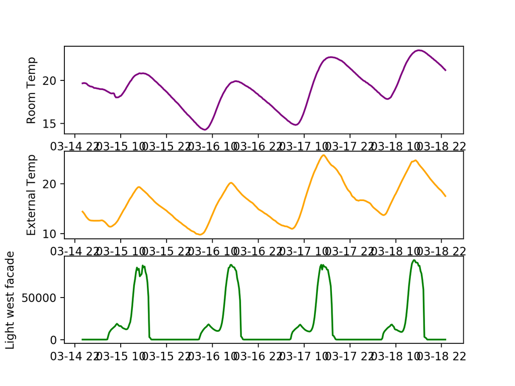

```python
ChosenDatas_SelectedPeriod=ChosenDatas["2012-03-15 00:00:00":"2012-03-18 23:00:00"]

plt.figure("Chosen datas in selected period")
plt.subplot(3,1,1)
plt.plot(ChosenDatas_SelectedPeriod.iloc[:,0],color="purple")
plt.ylabel("Room Temp")
plt.subplot(3,1,2)
plt.plot(ChosenDatas_SelectedPeriod.iloc[:,1],color="orange")
plt.ylabel("External Temp")
plt.subplot(3,1,3)
plt.plot(ChosenDatas_SelectedPeriod.iloc[:,2],color="green")
plt.ylabel("Light west facade")
```

Since there are lags between datas, we use the command .corr() applied to external temperature and lighting in order to find the best correlation between them.

```python
Temperature_lag=ChosenDatas[["4:Temperature_Habitacion_Sensor"]].join(ChosenDatas[["22:Temperature_Exterior_Sensor"]])
Lighting_lag=ChosenDatas[["4:Temperature_Habitacion_Sensor"]].join(ChosenDatas[["15:Meteo_Exterior_Sol_Oest"]])

def lag_column(df,column_name,lag_period=1):
    for i in range(1,lag_period+1,1):
        new_column_name = column_name+" -"+str(i)+"hr"
        df[new_column_name]=(df[column_name]).shift(i)
    return df
```

```python
Temperature_lag=lag_column(Temperature_lag,"22:Temperature_Exterior_Sensor",24)
Temperature_lag_correlation = Temperature_lag.corr()
Temperature_lag_correlation.head()
```

|  | 4:Temperature_Habitacion_Sensor | 22:Temperature_Exterior_Sensor | 22:Temperature_Exterior_Sensor -1hr | 22:Temperature_Exterior_Sensor -2hr | 22:Temperature_Exterior_Sensor -3hr | 22:Temperature_Exterior_Sensor -4hr | 22:Temperature_Exterior_Sensor -5hr | 22:Temperature_Exterior_Sensor -6hr | 22:Temperature_Exterior_Sensor -7hr | 22:Temperature_Exterior_Sensor -8hr | ... | 22:Temperature_Exterior_Sensor -15hr | 22:Temperature_Exterior_Sensor -16hr | 22:Temperature_Exterior_Sensor -17hr | 22:Temperature_Exterior_Sensor -18hr | 22:Temperature_Exterior_Sensor -19hr | 22:Temperature_Exterior_Sensor -20hr | 22:Temperature_Exterior_Sensor -21hr | 22:Temperature_Exterior_Sensor -22hr | 22:Temperature_Exterior_Sensor -23hr | 22:Temperature_Exterior_Sensor -24hr |
| --- | --- | --- | --- | --- | --- | --- | --- | --- | --- | --- | --- | --- | --- | --- | --- | --- | --- | --- | --- | --- | --- |
| 4:Temperature_Habitacion_Sensor | 1.000000 | 0.863417 | 0.879529 | 0.892916 | 0.903545 | 0.911380 | 0.916406 | 0.918626 | 0.918076 | 0.914825 | ... | 0.824698 | 0.803865 | 0.781494 | 0.757746 | 0.732785 | 0.706770 | 0.679835 | 0.652111 | 0.623713 | 0.594783 |
| 22:Temperature_Exterior_Sensor | 0.863417 | 1.000000 | 0.997767 | 0.991546 | 0.981649 | 0.968143 | 0.951213 | 0.931029 | 0.907781 | 0.881744 | ... | 0.640223 | 0.599910 | 0.558820 | 0.517161 | 0.475117 | 0.432916 | 0.390764 | 0.348861 | 0.307367 | 0.266457 |
| 22:Temperature_Exterior_Sensor -1hr | 0.879529 | 0.997767 | 1.000000 | 0.997767 | 0.991546 | 0.981649 | 0.968144 | 0.951217 | 0.931035 | 0.907789 | ... | 0.679566 | 0.640267 | 0.599954 | 0.558865 | 0.517206 | 0.475166 | 0.432968 | 0.390819 | 0.348918 | 0.307425 |
| 22:Temperature_Exterior_Sensor -2hr | 0.892916 | 0.991546 | 0.997767 | 1.000000 | 0.997767 | 0.991546 | 0.981651 | 0.968148 | 0.951224 | 0.931045 | ... | 0.717678 | 0.679614 | 0.640316 | 0.600004 | 0.558916 | 0.517260 | 0.475223 | 0.433029 | 0.390883 | 0.348983 |
| 22:Temperature_Exterior_Sensor -3hr | 0.903545 | 0.981649 | 0.991546 | 0.997767 | 1.000000 | 0.997767 | 0.991548 | 0.981655 | 0.968155 | 0.951233 | ... | 0.754360 | 0.717727 | 0.679664 | 0.640366 | 0.600055 | 0.558970 | 0.517318 | 0.475285 | 0.433095 | 0.390951 |

5 rows × 26 columns

```python
Lighting_lag=lag_column(Lighting_lag,"15:Meteo_Exterior_Sol_Oest",24)
Lighting_lag_correlation = Lighting_lag.corr()
Lighting_lag_correlation.head()
```

|  | 4:Temperature_Habitacion_Sensor | 15:Meteo_Exterior_Sol_Oest | 15:Meteo_Exterior_Sol_Oest -1hr | 15:Meteo_Exterior_Sol_Oest -2hr | 15:Meteo_Exterior_Sol_Oest -3hr | 15:Meteo_Exterior_Sol_Oest -4hr | 15:Meteo_Exterior_Sol_Oest -5hr | 15:Meteo_Exterior_Sol_Oest -6hr | 15:Meteo_Exterior_Sol_Oest -7hr | 15:Meteo_Exterior_Sol_Oest -8hr | ... | 15:Meteo_Exterior_Sol_Oest -15hr | 15:Meteo_Exterior_Sol_Oest -16hr | 15:Meteo_Exterior_Sol_Oest -17hr | 15:Meteo_Exterior_Sol_Oest -18hr | 15:Meteo_Exterior_Sol_Oest -19hr | 15:Meteo_Exterior_Sol_Oest -20hr | 15:Meteo_Exterior_Sol_Oest -21hr | 15:Meteo_Exterior_Sol_Oest -22hr | 15:Meteo_Exterior_Sol_Oest -23hr | 15:Meteo_Exterior_Sol_Oest -24hr |
| --- | --- | --- | --- | --- | --- | --- | --- | --- | --- | --- | --- | --- | --- | --- | --- | --- | --- | --- | --- | --- | --- |
| 4:Temperature_Habitacion_Sensor | 1.000000 | 0.335288 | 0.354079 | 0.370842 | 0.385760 | 0.398868 | 0.410045 | 0.419253 | 0.426467 | 0.431807 | ... | 0.421584 | 0.414284 | 0.405744 | 0.396090 | 0.385396 | 0.373752 | 0.361186 | 0.347751 | 0.333539 | 0.318561 |
| 15:Meteo_Exterior_Sol_Oest | 0.335288 | 1.000000 | 0.971473 | 0.924595 | 0.869015 | 0.805361 | 0.734780 | 0.659717 | 0.582818 | 0.504508 | ... | 0.022512 | -0.017913 | -0.046829 | -0.067491 | -0.082176 | -0.091553 | -0.096916 | -0.101029 | -0.104805 | -0.109204 |
| 15:Meteo_Exterior_Sol_Oest -1hr | 0.354079 | 0.971473 | 1.000000 | 0.971473 | 0.924600 | 0.869025 | 0.805369 | 0.734783 | 0.659715 | 0.582811 | ... | 0.073861 | 0.022467 | -0.017961 | -0.046879 | -0.067543 | -0.082228 | -0.091606 | -0.096969 | -0.101082 | -0.104858 |
| 15:Meteo_Exterior_Sol_Oest -2hr | 0.370842 | 0.924595 | 0.971473 | 1.000000 | 0.971475 | 0.924605 | 0.869027 | 0.805366 | 0.734775 | 0.659701 | ... | 0.134225 | 0.073802 | 0.022404 | -0.018027 | -0.046947 | -0.067612 | -0.082299 | -0.091677 | -0.097041 | -0.101154 |
| 15:Meteo_Exterior_Sol_Oest -3hr | 0.385760 | 0.869015 | 0.924600 | 0.971475 | 1.000000 | 0.971474 | 0.924601 | 0.869018 | 0.805351 | 0.734753 | ... | 0.201512 | 0.134146 | 0.073717 | 0.022314 | -0.018121 | -0.047044 | -0.067711 | -0.082399 | -0.091778 | -0.097142 |

5 rows × 26 columns

```python
ChosenDatas_cleaned = ChosenDatas.dropna()
ChosenDatas_cleaned["22:Temperature_Exterior_Sensor"]=ChosenDatas_cleaned["22:Temperature_Exterior_Sensor"].shift(-6)
ChosenDatas_cleaned["15:Meteo_Exterior_Sol_Oest"]=ChosenDatas_cleaned["15:Meteo_Exterior_Sol_Oest"].shift(-8)
ChosenDatas_cleaned.head()
```

| Date_and_time | 4:Temperature_Habitacion_Sensor | 22:Temperature_Exterior_Sensor | 15:Meteo_Exterior_Sol_Oest |
| --- | --- | --- | --- |
| 2012-03-13 11:45:00 | 17.8275 | 20.5660 | 71453.4 |
| 2012-03-13 12:00:00 | 18.1207 | 20.8427 | 80076.8 |
| 2012-03-13 12:15:00 | 18.4367 | 21.2040 | 86682.3 |
| 2012-03-13 12:30:00 | 18.7513 | 21.5227 | 88648.4 |
| 2012-03-13 12:45:00 | 19.0414 | 21.7560 | 91406.3 |

To obtain a correct representation of the data on the unique plot we have to normalized all datas and plotting them on the selected period.

```python
TempRoom_min=ChosenDatas_cleaned["4:Temperature_Habitacion_Sensor"].min()
TempRoom_max=ChosenDatas_cleaned["4:Temperature_Habitacion_Sensor"].max()
TempExt_min=ChosenDatas_cleaned["22:Temperature_Exterior_Sensor"].min()
TempExt_max=ChosenDatas_cleaned["22:Temperature_Exterior_Sensor"].max()
LightWest_min=ChosenDatas_cleaned["15:Meteo_Exterior_Sol_Oest"].min()
LightWest_max=ChosenDatas_cleaned["15:Meteo_Exterior_Sol_Oest"].max()
ChosenDatas_cleaned["TempRoom_normalized"]=(ChosenDatas_cleaned["4:Temperature_Habitacion_Sensor"]-TempRoom_min)/(TempRoom_max-TempRoom_min)
ChosenDatas_cleaned["TempExt_normalized"]=(ChosenDatas_cleaned["22:Temperature_Exterior_Sensor"]-TempExt_min)/(TempExt_max-TempExt_min)
ChosenDatas_cleaned["LightWest_normalized"]=(ChosenDatas_cleaned["15:Meteo_Exterior_Sol_Oest"]-LightWest_min)/(LightWest_max-LightWest_min)
ChosenDatas_cleaned.head()
ChosenDatas_cleaned.describe()
```

|  | 4:Temperature_Habitacion_Sensor | 22:Temperature_Exterior_Sensor | 15:Meteo_Exterior_Sol_Oest | TempRoom_normalized | TempExt_normalized | LightWest_normalized |
| --- | --- | --- | --- | --- | --- | --- |
| count | 2764.000000 | 2758.000000 | 2756.000000 | 2764.000000 | 2758.000000 | 2756.000000 |
| mean | 18.824852 | 16.752759 | 14897.396384 | 0.558758 | 0.364010 | 0.156356 |
| std | 2.821178 | 3.888418 | 25973.257481 | 0.203431 | 0.187985 | 0.272604 |
| min | 11.076000 | 9.223330 | 0.000000 | 0.000000 | 0.000000 | 0.000000 |
| 25% | 17.060350 | 13.653025 | 0.000000 | 0.431522 | 0.214154 | 0.000000 |
| 50% | 19.021000 | 16.458650 | 0.000000 | 0.572902 | 0.349791 | 0.000000 |
| 75% | 20.828700 | 19.394150 | 15065.575000 | 0.703252 | 0.491708 | 0.158122 |
| max | 24.944000 | 29.908000 | 95278.400000 | 1.000000 | 1.000000 | 1.000000 |

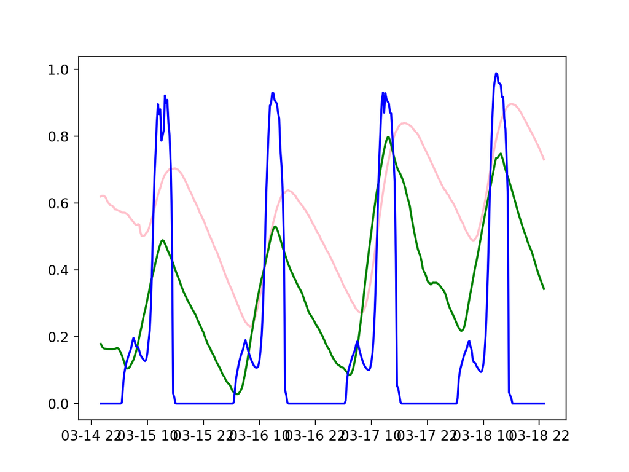

```python
ChosenDatas_cleaned_SelectedPeriod=ChosenDatas_cleaned["2012-03-15 00:00:00":"2012-03-18 23:00:00"]

plt.figure("Normalized datas in selected period")
plt.plot(ChosenDatas_cleaned_SelectedPeriod.iloc[:,3],color="pink")
plt.plot(ChosenDatas_cleaned_SelectedPeriod.iloc[:,4],color="green")
plt.plot(ChosenDatas_cleaned_SelectedPeriod.iloc[:,5],color="blue")
```

We create a new dataframe only with normalized values.

```python
TempRoom_Norm=ChosenDatas_cleaned[["TempRoom_normalized"]]
TempExt_Norm=ChosenDatas_cleaned[["TempExt_normalized"]]
LighWest_Norm=ChosenDatas_cleaned[["LightWest_normalized"]]
Database_Norm=TempRoom_Norm.join([TempExt_Norm,LighWest_Norm])
```

```python
df=Database_Norm
lag_start=1
lag_end=24
lag_interval=1
column_name="TempRoom_normalized"

for i in range(lag_start, lag_end+1, lag_interval):
    new_column_name=column_name+" -"+str(i)+"hr"
    print new_column_name
    df[new_column_name]=df[column_name].shift(i)
    df.dropna(inplace=True)
df.head()

def lag_feature (df,column_name,lag_start, lag_end, lag_interval):
    for i in range(lag_start, lag_end+1, lag_interval):
        new_column_name=column_name+" -"+str(i)+"hr"
        print new_column_name
        df[new_column_name]=df[column_name].shift(i)
        df.dropna(inplace=True)
    return df
```

```
TempRoom_normalized -1hr
TempRoom_normalized -2hr
TempRoom_normalized -3hr
TempRoom_normalized -4hr
TempRoom_normalized -5hr
TempRoom_normalized -6hr
TempRoom_normalized -7hr
TempRoom_normalized -8hr
TempRoom_normalized -9hr
TempRoom_normalized -10hr
TempRoom_normalized -11hr
TempRoom_normalized -12hr
TempRoom_normalized -13hr
TempRoom_normalized -14hr
TempRoom_normalized -15hr
TempRoom_normalized -16hr
TempRoom_normalized -17hr
TempRoom_normalized -18hr
TempRoom_normalized -19hr
TempRoom_normalized -20hr
TempRoom_normalized -21hr
TempRoom_normalized -22hr
TempRoom_normalized -23hr
TempRoom_normalized -24hr
```

```python
Database_Lag=lag_column(Database_Norm,"TempRoom_normalized",24)

FinalDatabase=Database_Lag.dropna()
FinalDatabase.head()
```

| Date_and_time | TempRoom_normalized | TempExt_normalized | LightWest_normalized | TempRoom_normalized -1hr | TempRoom_normalized -2hr | TempRoom_normalized -3hr | TempRoom_normalized -4hr | TempRoom_normalized -5hr | TempRoom_normalized -6hr | TempRoom_normalized -7hr | ... | TempRoom_normalized -15hr | TempRoom_normalized -16hr | TempRoom_normalized -17hr | TempRoom_normalized -18hr | TempRoom_normalized -19hr | TempRoom_normalized -20hr | TempRoom_normalized -21hr | TempRoom_normalized -22hr | TempRoom_normalized -23hr | TempRoom_normalized -24hr |
| --- | --- | --- | --- | --- | --- | --- | --- | --- | --- | --- | --- | --- | --- | --- | --- | --- | --- | --- | --- | --- | --- |
| 2012-03-16 20:45:00 | 0.558069 | 0.269377 | 0.0 | 0.563888 | 0.568698 | 0.576053 | 0.581245 | 0.584655 | 0.592061 | 0.595039 | ... | 0.632442 | 0.635275 | 0.635513 | 0.638448 | 0.637727 | 0.635852 | 0.631764 | 0.629074 | 0.627394 | 0.621431 |
| 2012-03-16 21:00:00 | 0.551392 | 0.264576 | 0.0 | 0.558069 | 0.563888 | 0.568698 | 0.576053 | 0.581245 | 0.584655 | 0.592061 | ... | 0.627394 | 0.632442 | 0.635275 | 0.635513 | 0.638448 | 0.637727 | 0.635852 | 0.631764 | 0.629074 | 0.627394 |
| 2012-03-16 21:15:00 | 0.543791 | 0.258712 | 0.0 | 0.551392 | 0.558069 | 0.563888 | 0.568698 | 0.576053 | 0.581245 | 0.584655 | ... | 0.625231 | 0.627394 | 0.632442 | 0.635275 | 0.635513 | 0.638448 | 0.637727 | 0.635852 | 0.631764 | 0.629074 |
| 2012-03-16 21:30:00 | 0.536775 | 0.253553 | 0.0 | 0.543791 | 0.551392 | 0.558069 | 0.563888 | 0.568698 | 0.576053 | 0.581245 | ... | 0.620710 | 0.625231 | 0.627394 | 0.632442 | 0.635275 | 0.635513 | 0.638448 | 0.637727 | 0.635852 | 0.631764 |
| 2012-03-16 21:45:00 | 0.532254 | 0.246495 | 0.0 | 0.536775 | 0.543791 | 0.551392 | 0.558069 | 0.563888 | 0.568698 | 0.576053 | ... | 0.614652 | 0.620710 | 0.625231 | 0.627394 | 0.632442 | 0.635275 | 0.635513 | 0.638448 | 0.637727 | 0.635852 |

5 rows × 27 columns

# Machine learning

Now we are applying machine learning to the given data. With Machine learning we create mathematical models to help analyzing data. Once these models have been fit to previously seen datas, they can be used to predict and understand aspects of new datas.

To do this we have to divide our data in two macro categories: Training set and Test set. Training set is the part of data used to create the model and it's a list of pratictal examples in which we build the algorithm. The Test set is instead the part of data used to verify that the model works.

These forecasting measures could allow, in our case, the house to adapt itself to future temperature conditions by using home automation in an energy efficient manner. The first method available is Linear Regression.

## Linear regression model

```python
Target=FinalDatabase["TempRoom_normalized"]
Features=FinalDatabase.drop("TempRoom_normalized",axis=1)

from sklearn.model_selection import train_test_split
X_train, X_test, Y_train, Y_test = train_test_split(Features,Target,test_size = 0.2, random_state=41234)
```

```python
from sklearn import linear_model
linear_reg = linear_model.LinearRegression()

linear_reg.fit(X_train, Y_train)
predicted_linearReg_split = linear_reg.predict(X_test)

predicted_DF_linearReg_split=pd.DataFrame(predicted_linearReg_split,index=Y_test.index, columns=["RoomTemp_linearReg"])
predicted_DF_linearReg_split=predicted_DF_linearReg_split.join(Y_test)
```

Now we can see the results of our prediction with actual values on a plot

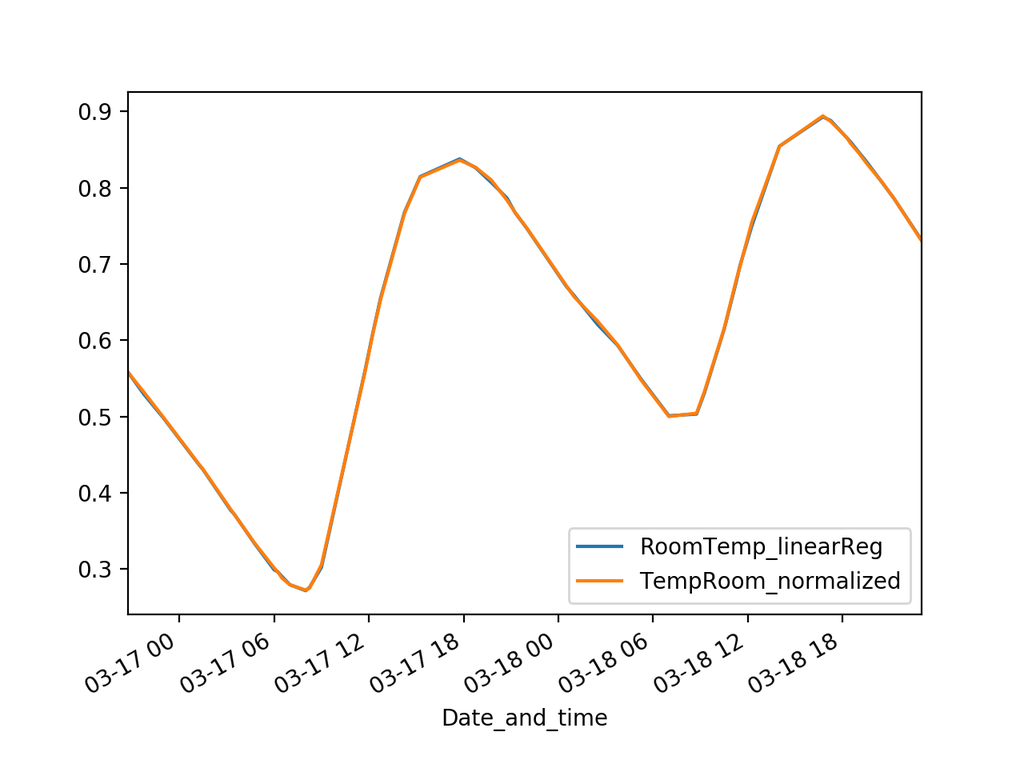

```python
predicted_DF_linearReg_split_SelectedPeriod=predicted_DF_linearReg_split["2012-03-15 00:00:00":"2012-03-18 23:00:00"]
predicted_DF_linearReg_split_SelectedPeriod.plot()
```

At the end we evaluate the square, absolute errors and R2 error.

```python
from sklearn.metrics import mean_absolute_error,mean_squared_error,r2_score
MAE_linearReg_split= mean_absolute_error(predicted_linearReg_split,Y_test)
MSE_linearReg_split= mean_squared_error(predicted_linearReg_split,Y_test)
R2_linearReg_split = r2_score(predicted_linearReg_split,Y_test)
```

```python
R2_linearReg_split
```

```
0.99955399103777698
```

```python
MSE_linearReg_split
```

```
1.7997650707215091e-05
```

```python
MAE_linearReg_split
```

```
0.0019464269643858203
```

## Cross validation

To choose more accurately our training set, we use k-fold cross validation. In this way we dont't choose random datas but we divide our total database in k parts.At any step, the kth part of the dataset becomes the validation set, the remaining is the training set.

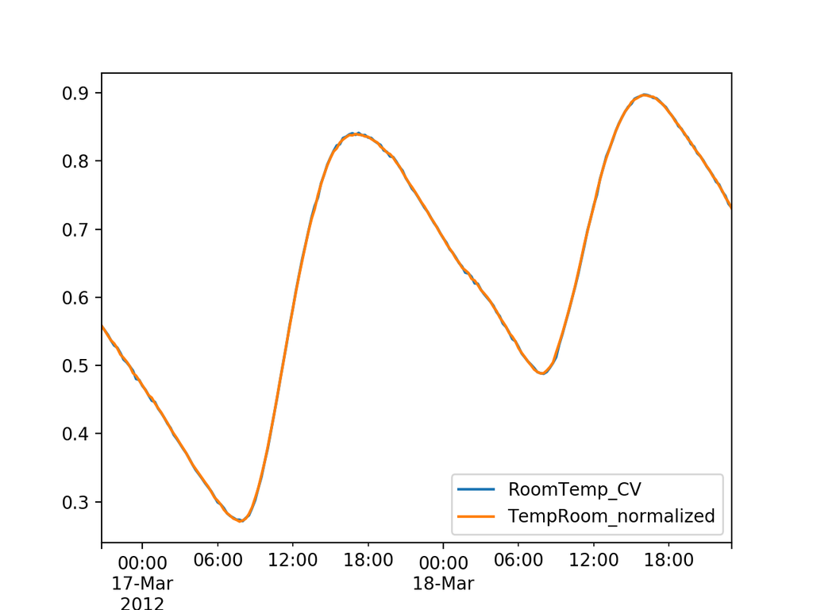

```python
from sklearn.model_selection import cross_val_predict
predict_CV = cross_val_predict(linear_reg,Features,Target,cv=10)
predicted_DF_CV=pd.DataFrame(predict_CV,index=Target.index,columns=["RoomTemp_CV"])
predicted_DF_CV=predicted_DF_CV.join(Target)
predicted_DF_CV_SelectedPeriod=predicted_DF_CV["2012-03-15 00:00:00":"2012-03-18 23:00:00"]
predicted_DF_CV_SelectedPeriod.plot()
```

At the end we evaluate the accurate of prediction calculating the error between the test datas and the predicted ones.

```python
MAE_CV= mean_absolute_error(predict_CV,Target)
MSE_CV= mean_squared_error(predict_CV,Target)
R2_CV= r2_score(predict_CV,Target)
```

```python
R2_CV
```

```
0.99979508584154553
```

```python
MAE_CV
```

```
0.0018116622153913375
```

```python
MSE_CV
```

```
8.8583027508925122e-06
```

## Random forest

The last method is based on decision trees.

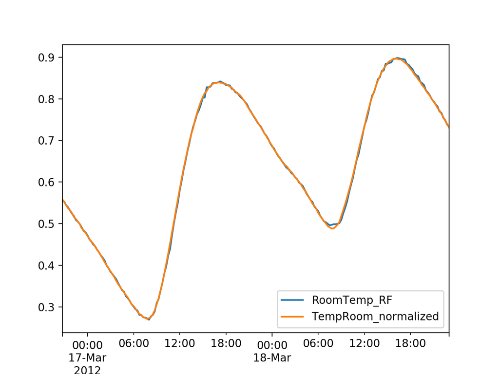

```python
from sklearn.ensemble import RandomForestRegressor
reg_RF = RandomForestRegressor()
predict_RF= cross_val_predict(reg_RF,Features,Target,cv=10)

predicted_DF_RF=pd.DataFrame(predict_RF,index=Target.index, columns=["RoomTemp_RF"])
predicted_DF_RF=predicted_DF_RF.join(Target)
predicted_DF_RF_SelectedPeriod=predicted_DF_RF["2012-03-15 00:00:00":"2012-03-18 23:00:00"]
predicted_DF_RF_SelectedPeriod.plot()
```

```python
MAE_RF_CV= mean_absolute_error(predict_RF,Target)
MSE_RF_CV= mean_squared_error(predict_RF,Target)
R2_RF_CV = r2_score(predict_RF,Target)
```

```python
R2_RF_CV
```

```
0.99896922279476019
```

```python
MSE_RF_CV
```

```
4.4391525909862374e-05
```

```python
MAE_RF_CV
```

```
0.0040578505195752968
```